# Estimating Customer Lifetime Value - Part 1

```python
import pandas as pd
import matplotlib.pyplot as plt
import seaborn as sns
import numpy as np
from wordcloud import WordCloud, ImageColorGenerator, STOPWORDS
```

# Dataset

This online retail dataset is from the UC Irvine Machine Learning Repository: https://archive.ics.uci.edu/dataset/502/online+retail+ii.

Our goal is to estimate customers' gross spend in the next one year as an effort to understand customer lifetime value.

First, we will load the data and display some basic metadata.

```python
df1 = pd.read_excel('./online_retail_II.xlsx', sheet_name=0) # Year 2009-2010
df2 = pd.read_excel('./online_retail_II.xlsx', sheet_name=1) # Year 2010-2011
df = pd.concat([df1, df2])
```

```python
df.shape
```

```
(1067371, 8)
```

```python
df.head()
```

|  | Invoice | StockCode | Description | Quantity | InvoiceDate | Price | Customer ID | Country |
| --- | --- | --- | --- | --- | --- | --- | --- | --- |
| 0 | 489434 | 85048 | 15CM CHRISTMAS GLASS BALL 20 LIGHTS | 12 | 2009-12-01 07:45:00 | 6.95 | 13085.0 | United Kingdom |
| 1 | 489434 | 79323P | PINK CHERRY LIGHTS | 12 | 2009-12-01 07:45:00 | 6.75 | 13085.0 | United Kingdom |
| 2 | 489434 | 79323W | WHITE CHERRY LIGHTS | 12 | 2009-12-01 07:45:00 | 6.75 | 13085.0 | United Kingdom |
| 3 | 489434 | 22041 | RECORD FRAME 7" SINGLE SIZE | 48 | 2009-12-01 07:45:00 | 2.10 | 13085.0 | United Kingdom |
| 4 | 489434 | 21232 | STRAWBERRY CERAMIC TRINKET BOX | 24 | 2009-12-01 07:45:00 | 1.25 | 13085.0 | United Kingdom |

```python
df['InvoiceDate'].min(), df['InvoiceDate'].max()
```

```
(Timestamp('2009-12-01 07:45:00'), Timestamp('2011-12-09 12:50:00'))
```

# Understand the Data

Let's perform Exploratory Data Analysis on the first 18 months of data. We will leave the most recent 6 months aside. This ensures any procedures we derive from the former can also generalize to the unseen data.

```python
start_date = pd.to_datetime('2009-12-01')
end_date = pd.to_datetime(start_date)+pd.DateOffset(months=18)
df_explore = df.loc[(df['InvoiceDate'] > start_date) & (df['InvoiceDate'] < end_date)]

df_explore['InvoiceDate'].min(), df_explore['InvoiceDate'].max()
```

```
(Timestamp('2009-12-01 07:45:00'), Timestamp('2011-05-31 15:53:00'))
```

## Missing Values

First, let's see if there are any missing values.

```python
def num_missing_by_columns(df):
    num_missing = df.isnull().sum().sort_values(ascending=False)
    percent = (df.isnull().sum()/len(df)).sort_values(ascending=False)
    missing_data = pd.concat([num_missing, percent], axis=1, keys=['Missing', 'Percent'])
    return missing_data

num_missing_by_columns(df_explore)
```

|  | Missing | Percent |
| --- | --- | --- |
| Customer ID | 167903 | 0.228598 |
| Description | 3761 | 0.005121 |
| Invoice | 0 | 0.000000 |
| StockCode | 0 | 0.000000 |
| Quantity | 0 | 0.000000 |
| InvoiceDate | 0 | 0.000000 |
| Price | 0 | 0.000000 |
| Country | 0 | 0.000000 |

Customer ID has a high percentage of missing values. For our purpose, we will need to drop records from unknown customers since we need to track the dollar spend per customer to estimate lifetime value.

Let's take a look at the distributions of some fields

## Data Distributions

```python
df_explore['Invoice'].nunique(), df_explore['Customer ID'].nunique()
```

```
(38511, 4998)
```

```python
df_explore['Quantity'].describe()
```

```
count    734490.000000
mean         10.051308
std         155.126389
min      -74215.000000
25%           1.000000
50%           3.000000
75%          10.000000
max       74215.000000
Name: Quantity, dtype: float64
```

```python
df_explore['Price'].describe()
```

```
count    734490.000000
mean          4.786803
std         133.486941
min      -53594.360000
25%           1.250000
50%           2.100000
75%           4.210000
max       25111.090000
Name: Price, dtype: float64
```

Upon inspection, quantity can be negative. Let's pull some out to verify.

```python
df_explore[df_explore['Quantity'] < 0].head()
```

|  | Invoice | StockCode | Description | Quantity | InvoiceDate | Price | Customer ID | Country |
| --- | --- | --- | --- | --- | --- | --- | --- | --- |
| 178 | C489449 | 22087 | PAPER BUNTING WHITE LACE | -12 | 2009-12-01 10:33:00 | 2.95 | 16321.0 | Australia |
| 179 | C489449 | 85206A | CREAM FELT EASTER EGG BASKET | -6 | 2009-12-01 10:33:00 | 1.65 | 16321.0 | Australia |
| 180 | C489449 | 21895 | POTTING SHED SOW 'N' GROW SET | -4 | 2009-12-01 10:33:00 | 4.25 | 16321.0 | Australia |
| 181 | C489449 | 21896 | POTTING SHED TWINE | -6 | 2009-12-01 10:33:00 | 2.10 | 16321.0 | Australia |
| 182 | C489449 | 22083 | PAPER CHAIN KIT RETRO SPOT | -12 | 2009-12-01 10:33:00 | 2.95 | 16321.0 | Australia |

This looks like returns. The price and quantity distributions earlier also shows some outliers. Let's examine them.

## Outliers

```python
df_explore.sort_values(by='Price', ascending=False).head()
```

|  | Invoice | StockCode | Description | Quantity | InvoiceDate | Price | Customer ID | Country |
| --- | --- | --- | --- | --- | --- | --- | --- | --- |
| 241824 | C512770 | M | Manual | -1 | 2010-06-17 16:52:00 | 25111.09 | 17399.0 | United Kingdom |
| 241827 | 512771 | M | Manual | 1 | 2010-06-17 16:53:00 | 25111.09 | NaN | United Kingdom |
| 320581 | C520667 | BANK CHARGES | Bank Charges | -1 | 2010-08-27 13:42:00 | 18910.69 | NaN | United Kingdom |
| 43702 | C540117 | AMAZONFEE | AMAZON FEE | -1 | 2011-01-05 09:55:00 | 16888.02 | NaN | United Kingdom |
| 43703 | C540118 | AMAZONFEE | AMAZON FEE | -1 | 2011-01-05 09:57:00 | 16453.71 | NaN | United Kingdom |

```python
df_explore.sort_values(by='Quantity', ascending=False).head()
```

|  | Invoice | StockCode | Description | Quantity | InvoiceDate | Price | Customer ID | Country |
| --- | --- | --- | --- | --- | --- | --- | --- | --- |
| 61619 | 541431 | 23166 | MEDIUM CERAMIC TOP STORAGE JAR | 74215 | 2011-01-18 10:01:00 | 1.04 | 12346.0 | United Kingdom |
| 90857 | 497946 | 37410 | BLACK AND WHITE PAISLEY FLOWER MUG | 19152 | 2010-02-15 11:57:00 | 0.10 | 13902.0 | Denmark |
| 127166 | 501534 | 21099 | SET/6 STRAWBERRY PAPER CUPS | 12960 | 2010-03-17 13:09:00 | 0.10 | 13902.0 | Denmark |
| 127168 | 501534 | 21091 | SET/6 WOODLAND PAPER PLATES | 12960 | 2010-03-17 13:09:00 | 0.10 | 13902.0 | Denmark |
| 127169 | 501534 | 21085 | SET/6 WOODLAND PAPER CUPS | 12744 | 2010-03-17 13:09:00 | 0.10 | 13902.0 | Denmark |

Oops, looks like there are stock code that are not product-related. While the top quantity records are fine, the top priced records do not look relevant. Let's break down the stock codes further.

## Stock Codes

```python
df_explore.loc[:,['StockCodeLen']] = df_explore['StockCode'].astype(str).str.len()

df_explore\
.groupby('StockCodeLen')\
.apply(lambda x: pd.Series({
    'codes': x['StockCode'].unique(),
    'descriptions': x['Description'].str.strip().unique(),
    }))\
.reset_index()
```

|  | StockCodeLen | codes | descriptions |
| --- | --- | --- | --- |
| 0 | 1 | [D, M, m, S, B] | [Discount, Manual, SAMPLES, Adjust bad debt] |
| 1 | 2 | [C2, C3] | [CARRIAGE, nan] |
| 2 | 3 | [DOT] | [DOTCOM POSTAGE, nan] |
| 3 | 4 | [POST, PADS, GIFT] | [POSTAGE, PADS TO MATCH ALL CUSHIONS, nan] |
| 4 | 5 | [85048, 22041, 21232, 22064, 21871, 21523, 223... | [15CM CHRISTMAS GLASS BALL 20 LIGHTS, RECORD F... |
| 5 | 6 | [79323P, 79323W, 48173C, 35004B, 84596F, 84596... | [PINK CHERRY LIGHTS, WHITE CHERRY LIGHTS, DOOR... |
| 6 | 7 | [79323LP, 15056BL, 79323GR, 15056bl, TEST001, ... | [LIGHT PINK CHERRY LIGHTS, EDWARDIAN PARASOL B... |
| 7 | 8 | [DCGS0058, DCGS0068, DCGS0004, DCGS0076, DCGS0... | [MISO PRETTY GUM, DOGS NIGHT COLLAR, HAYNES C... |
| 8 | 9 | [DCGS0066N, DCGSSGIRL, DCGSLGIRL, AMAZONFEE] | [NAVY CUDDLES DOG HOODIE, nan, update, GIRLS P... |
| 9 | 12 | [BANK CHARGES, gift_0001_80, gift_0001_20, gif... | [Bank Charges, nan, Dotcomgiftshop Gift Vouche... |

There are quite a few non-product stock codes:

- C2: Carriage
- DOT: Postage
- POST: Postage
- Test001: Test Product
- Test002: Test Product
- Bank Charges: Bank Charges
- etc...

Many of these are expenses. Our goal is to measure customers' gross spends so it should be fine to remove these. For simplicity, we will use some heuristics to do the filtering - we want the stock code to be between 5 and 8 characters, and include numbers.

```python
def include_stock_code(code):
    if len(code) < 5 or len(code) > 8:
        return False

    if 'TEST' in code:
        return False

    for c in code:
        if c.isnumeric():
            return True

    return False

df_explore = df_explore[df_explore.apply(lambda x: include_stock_code(str(x['StockCode'])), axis=1)]
```

Finally, let's generate a word cloud on the item description. We will turn this information into an embedding during feature engineering, but for now this will give us a sense of what the customers are buying.

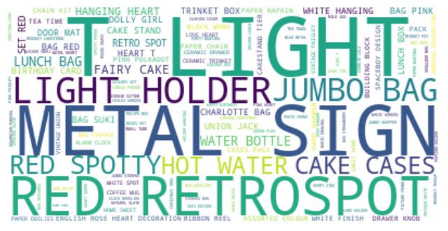

```python
descriptions = " ".join(d for d in df_explore['Description'].astype(str))
stopwords = set(STOPWORDS)
wordcloud = WordCloud(stopwords=stopwords, background_color="white").generate(descriptions)

plt.figure( figsize=(8,6))
plt.imshow(wordcloud, interpolation='bilinear')
plt.axis("off")
plt.show()
```

# Data Insights

Let's dig into the data and ask some questions. In order to calculate the customer value in future periods, we first need to know if the customers are returning at all. We will include only purchases for the analyses below.

```python
# first 18 months of data
df_eda = df_explore.loc[(df_explore['Quantity'] > 0) & (~df_explore['Customer ID'].isna())]
```

## Returning customers

```python
# label whether a customer has purchased from the store before
df_eda.loc[:, ['YearMonth']] = df_eda['InvoiceDate'].dt.to_period('M')
minInvoiceDates = df_eda.groupby('Customer ID')\
    .apply(lambda x: pd.Series({
        'minYearMonth': x['YearMonth'].min(),
        }))\
    .reset_index()

df_eda_dated = pd.merge(df_eda, minInvoiceDates, on='Customer ID', how='left')
df_eda_dated['is_return_customer'] = np.where(df_eda_dated['YearMonth'] > df_eda_dated['minYearMonth'], 1, 0)
```

```python
# aggregate the return customer count by month
return_customers_by_month = df_eda_dated.groupby(['Customer ID', 'YearMonth'])\
    .apply(lambda x: pd.Series({
        'is_return_customer': x['is_return_customer'].max(),
        'minYearMonth': x['minYearMonth'].min(),
    }))\
    .reset_index()

return_percent = return_customers_by_month.groupby('YearMonth')\
    .apply(lambda x: pd.Series({
        'num_return_customers': x['is_return_customer'].sum(),
        'total_num_customers': len(x)
    }))\
    .reset_index()
return_percent['percent'] = return_percent['num_return_customers']/return_percent['total_num_customers']
```

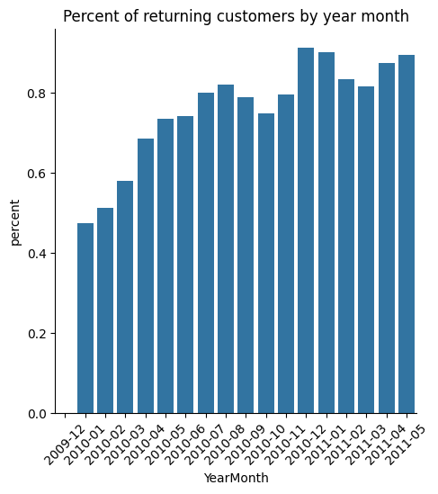

```python
# plotting it out
sns.catplot(x='YearMonth', y='percent', kind='bar', data=return_percent)
plt.title('Percent of returning customers by year month');
plt.xticks(rotation=45);
```

## Cohort Analysis

In particular, we will use customers from the first 3 months as our cohort, and examine their retention rate.

```python
cohort_cutoff = '2010-03-01'
cohort = df_eda.loc[df_eda['InvoiceDate'] < pd.to_datetime(cohort_cutoff), ['Customer ID']].drop_duplicates()
```

```python
df_cohort = pd.merge(df_eda[df_eda['InvoiceDate'] >= pd.to_datetime(cohort_cutoff)], cohort, on='Customer ID', how='inner')
df_cohort['spend'] = df_cohort['Quantity'] * df_cohort['Price']
```

```python
cohort_analysis = df_cohort.groupby(['YearMonth'])\
    .apply(lambda x: pd.Series({
        'num_customers': x['Customer ID'].nunique(),
        'num_invoices': x['Invoice'].nunique(),
        'avg_spend_per_invoice': x['spend'].sum() / x['Invoice'].nunique(),
    }))\
    .reset_index()

cohort_analysis['percent'] = cohort_analysis['num_customers']/cohort.shape[0]
cohort_analysis['frequency_per_customer'] = cohort_analysis['num_invoices']/cohort_analysis['num_customers']
cohort_analysis['YM'] = cohort_analysis['YearMonth'].astype(str)
```

Below we plot three charts:

- the cohort retention rate,
- average spend per order and
- average number of orders per month

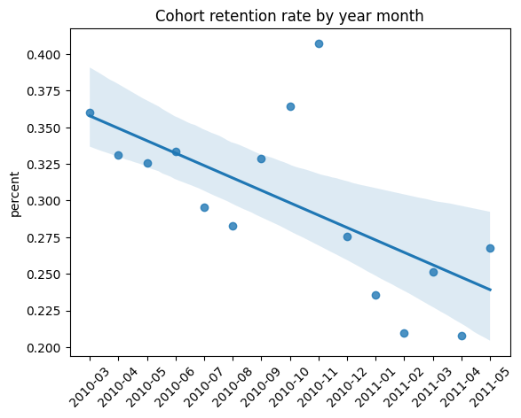

```python
sns.regplot(x=cohort_analysis['YM'].index, y='percent', data=cohort_analysis)
plt.title('Cohort retention rate by year month');
plt.xticks(cohort_analysis['YM'].index, cohort_analysis['YM'], rotation=45);
```

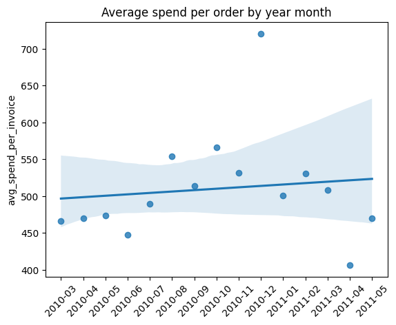

```python
sns.regplot(x=cohort_analysis['YM'].index, y='avg_spend_per_invoice', data=cohort_analysis)
plt.title('Average spend per order by year month');
plt.xticks(cohort_analysis['YM'].index, cohort_analysis['YM'], rotation=45);
```

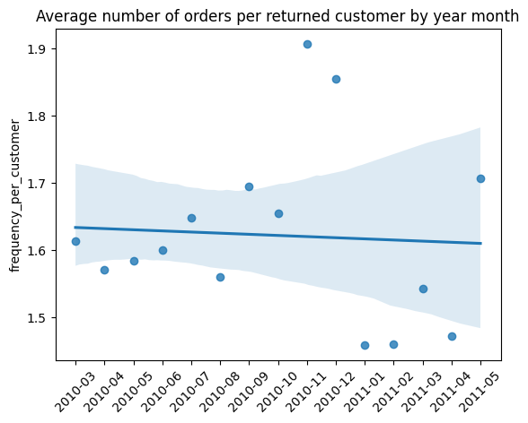

```python
sns.regplot(x=cohort_analysis['YM'].index, y='frequency_per_customer', data=cohort_analysis)
plt.title('Average number of orders per returned customer by year month');
plt.xticks(cohort_analysis['YM'].index, cohort_analysis['YM'], rotation=45);
```

# Baseline

```python
cohort_analysis['percent'].mean(), cohort_ana['avg_spend_per_invoice'].mean(), cohort_ana['frequency_per_customer'].mean()
```

```
(0.2984258166076348, 510.04903553906735, 1.6215743735133976)
```

Using the above, we can set up a baseline for estimating future 1-year customer value with

- 510 spend per invoice per month * 1.62 orders per month * 12 months * 30% retention rate

```python
510 * 1.62 * 12 * 0.3
```

```
2974.32
```

In the future, we will use the more advanced methods to estimate the customer 1-year gross spend and compare with this basline.